# 2015 Boston Marathon Results Analysis

Joshua Gardner - jpgard.com

April 5, 2016

# Data Preprocessing

```r
library(plyr)
library(lubridate)
```

```r
library(ggplot2)
results = read.csv("resultsfinal.csv", stringsAsFactors=FALSE)

#create divisions for age groups, based on agr goups listed at http://raceday.baa.org/statistics.html
results$age_group = cut(results$age, breaks = c(0, 35, 40, 45, 50, 55, 60, 65, 70, 75, 80), labels = c("18-34", "35-39", "40-44", "45-49", "50-54", "60-64", "65-69", "70-74", "75-79", "80+"), right = FALSE, ordered_result = TRUE)

#import qualifying times and add to data
qualTimes = read.table("qualifyingTimes.txt", sep = '\t', colClasses = c("factor", "factor", "character"))
names(qualTimes) = c("age_group", "gender", "qualifying_time")

#convert gender, county_origin to factor variables
results$gender = factor(results$gender); results$gender = factor(results$gender); results$county = factor(results$county)

results = merge(results, qualTimes)

#convert times to duration objects using as.difftime() and lubridate's as.duration()

results$X5k <- as.duration(as.difftime(tim = results$X5k, format = "%T", units = "secs"))
results$X10k <- as.duration(as.difftime(tim = results$X10k, format = "%T", units = "secs"))
results$X15k <- as.duration(as.difftime(tim = results$X15k, format = "%T", units = "secs"))
results$X20k <- as.duration(as.difftime(tim = results$X20k, format = "%T", units = "secs"))
results$half <- as.duration(as.difftime(tim = results$half, format = "%T", units = "secs"))
results$X25k <- as.duration(as.difftime(tim = results$X25k, format = "%T", units = "secs"))
results$X30k <- as.duration(as.difftime(tim = results$X30k, format = "%T", units = "secs"))
results$X35k <- as.duration(as.difftime(tim = results$X35k, format = "%T", units = "secs"))
results$X40k <- as.duration(as.difftime(tim = results$X40k, format = "%T", units = "secs"))
results$pace <- as.duration(as.difftime(tim = results$pace, format = "%T", units = "secs"))
results$official_time <- as.duration(as.difftime(tim = results$official_time, format = "%T", units = "secs"))
results$qualifying_time <- as.duration(as.difftime(tim = results$qualifying_time, format = "%T", units = "secs"))

#results$X5k <- as.POSIXlt(results$X5k, format = "%T")
#results$X10k <- as.POSIXlt(results$X10k, format = "%T")
#results$X15k <- as.POSIXlt(results$X15k, format = "%T")
#results$X20k <- as.POSIXlt(results$X20k, format = "%T")
#results$half <- as.POSIXlt(results$half, format = "%T")
#results$X25k <- as.POSIXlt(results$X25k, format = "%T")
#results$X30k <- as.POSIXlt(results$X30k, format = "%T")
#results$X35k <- as.POSIXlt(results$X35k, format = "%T")
#results$X40k <- as.POSIXlt(results$X40k, format = "%T")
#results$pace <- as.POSIXlt(results$pace, format = "%T")
#results$official_time <- as.POSIXlt(results$official_time, format = "%T")

#exclude any columns with na for any value; this removes 194 runners who didn't cross various checkpoints for any reasin (dropped out, missed checkpoint, foot RFID tag error...)
results = na.omit(results)
```

# Analysis: Four Guiding Questions

## 1. Who are the runners of the Boston Marathon?

#### Where do most runners come from, what are their ages, what genders are they?

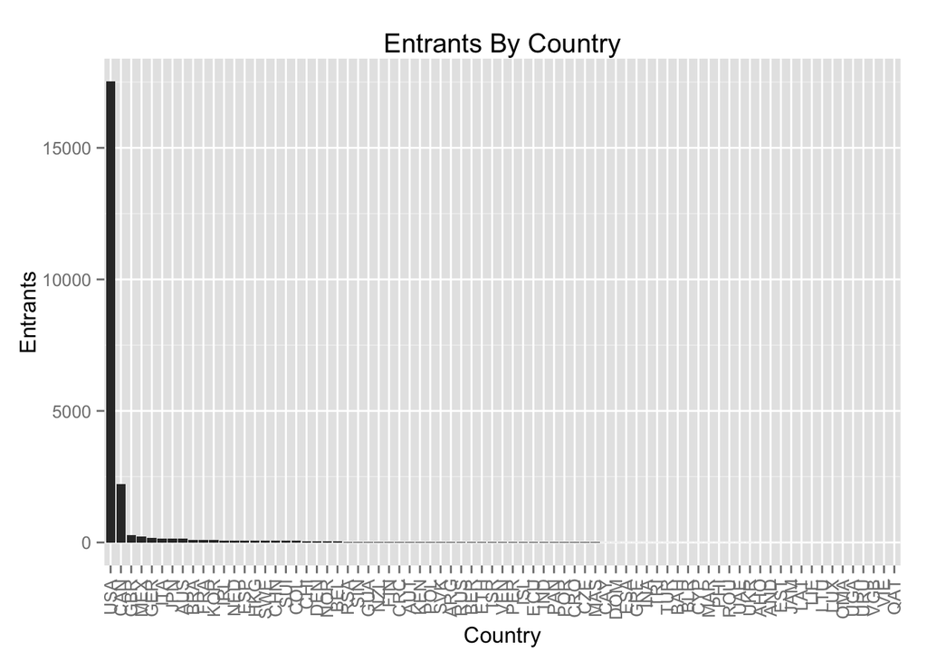

```r
countrycounts = data.frame(table(results$county))
names(countrycounts) <- c("Country", "Entrants")
ggplot(countrycounts, aes(x = reorder(Country, -Entrants), y = Entrants)) + geom_bar(stat="identity") + xlab("Country") + ggtitle("Entrants By Country") + theme(axis.text.x = element_text(angle = 90, hjust = 1, vjust = 0.5))
```

```r
#TODO: print top 10 sorted

#TODO: print countries with <5 entries just for fun?

#TODO: filled country map
```

Individually visualized, the age distributions of female (top) and male (bottom) runners are shown below:

```
## stat_bin: binwidth defaulted to range/30. Use 'binwidth = x' to adjust this.
## stat_bin: binwidth defaulted to range/30. Use 'binwidth = x' to adjust this.
```

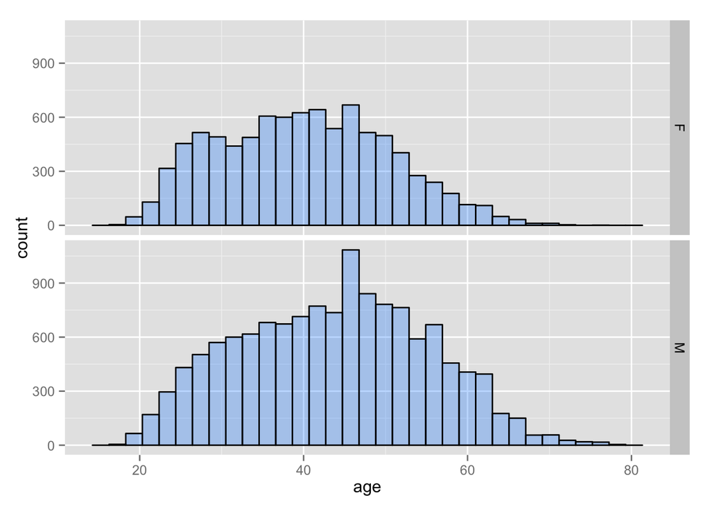

```r
ggplot(results, aes(x=age)) + geom_histogram(fill = "dodgerblue", colour="black", alpha = 0.3) + facet_grid(gender ~ .)
```

We can also directly compare the age distributions of male and female runners by overlaying them:

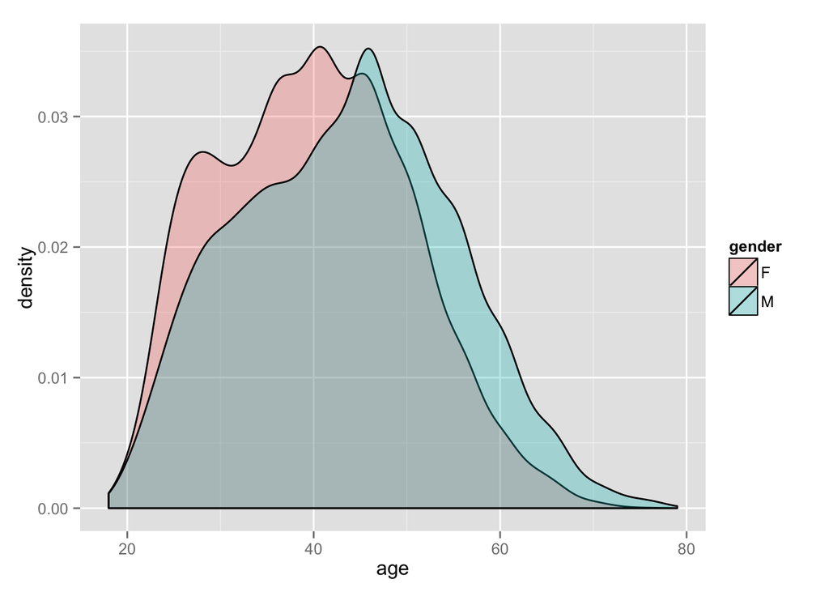

```r
ggplot(results, aes(x=age, fill = gender)) + geom_density(alpha = 0.3)
```

As seen above, females have a relatively higher proportion of runners younger than approximately 45 years of age, and males have a relatively higher proportion of runners older than 45 (although, in general, the distributions are wuite similar).

## 2. How fast are the runners of the Boston Marathon?

#### What are the average finishing times for men and women, and within age groups? How do these finishing times compare to the qualifying times needed to gain entry into the race?

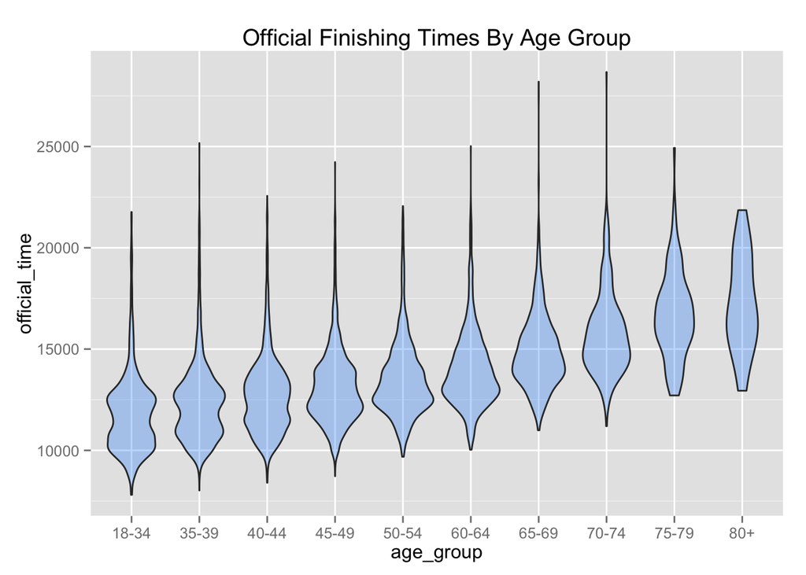

```r
ggplot(results, aes(x=age_group, y=official_time)) + geom_violin(fill = "dodgerblue", alpha = 0.3) + ggtitle("Official Finishing Times By Age Group")
```

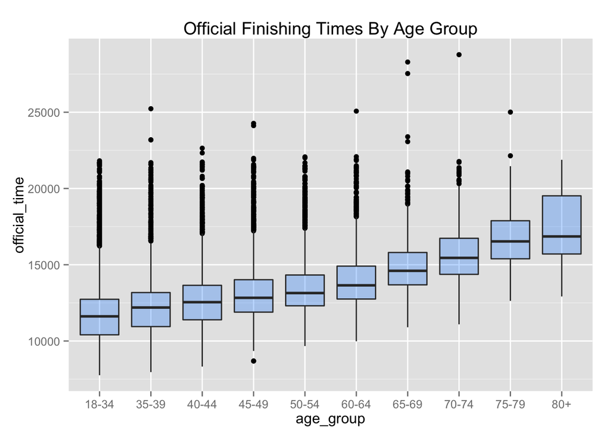

```r
ggplot(results, aes(x=age_group, y=official_time)) + geom_boxplot(fill = "dodgerblue", alpha = 0.3) + ggtitle("Official Finishing Times By Age Group")
```

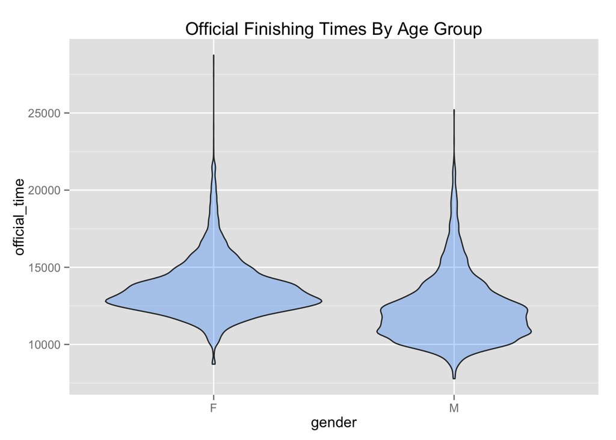

```r
ggplot(results, aes(x=gender, y=official_time)) + geom_violin(fill = "dodgerblue", alpha = 0.3) + ggtitle("Official Finishing Times By Age Group")
```

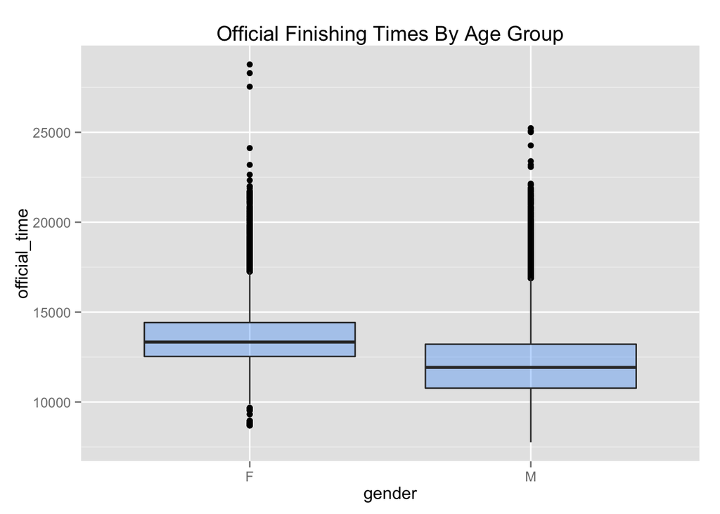

```r
ggplot(results, aes(x=gender, y=official_time)) + geom_boxplot(fill = "dodgerblue", alpha = 0.3) + ggtitle("Official Finishing Times By Age Group")
```

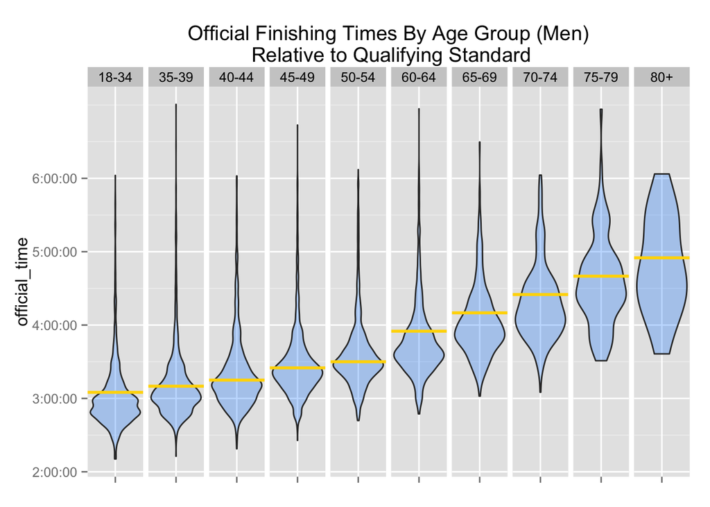

```r
#TODO: create faceted plot for each age group; in each facet, plot a horizontal line with the qualifying time for that group.
ggplot(subset(results, gender == "M"), aes(x=gender, y=official_time)) + geom_violin(fill = "dodgerblue", alpha = 0.3) + ggtitle("Official Finishing Times By Age Group (Men)\n Relative to Qualifying Standard")  + geom_hline(aes(yintercept=qualifying_time), size=1, colour = "gold") + facet_grid(. ~ age_group) + theme(axis.text.x = element_blank(), axis.title.x=element_blank()) + scale_y_continuous(breaks=c(3600, 7200, 10800, 14400, 18000, 21600), labels=c("1:00:00","2:00:00", "3:00:00", "4:00:00", "5:00:00", "6:00:00"))
```

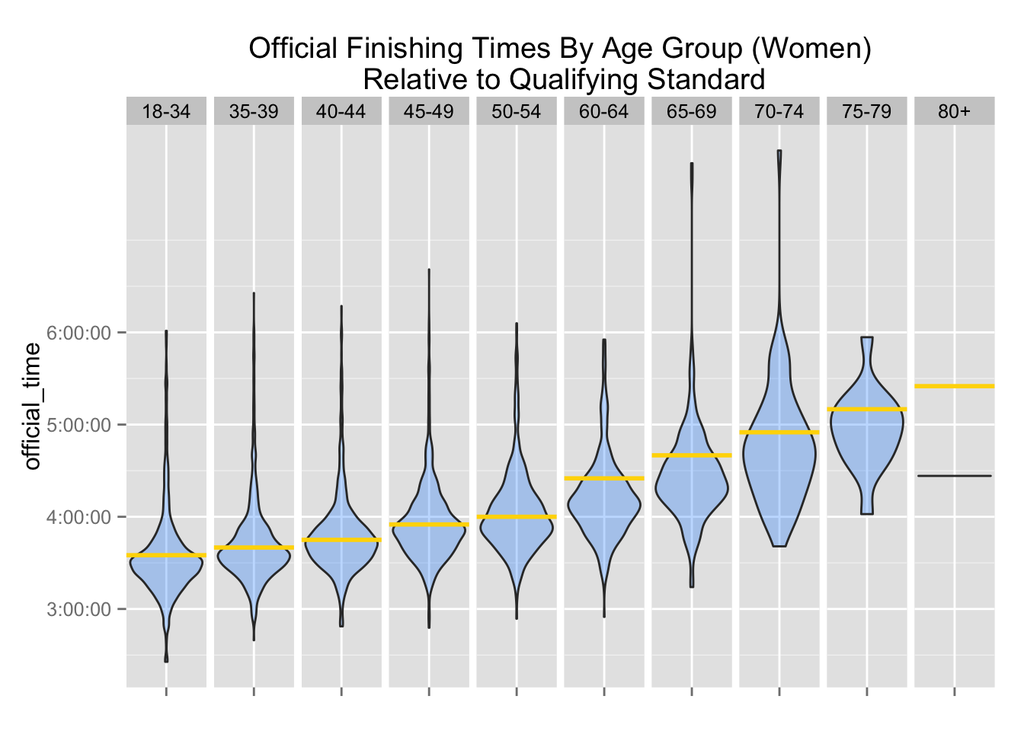

```r
ggplot(subset(results, gender == "F"), aes(x=gender, y=official_time)) + geom_violin(fill = "dodgerblue", alpha = 0.3) + ggtitle("Official Finishing Times By Age Group (Women)\n Relative to Qualifying Standard")  + geom_hline(aes(yintercept=qualifying_time), size=1, colour = "gold") + facet_grid(. ~ age_group) + theme(axis.text.x = element_blank(), axis.title.x=element_blank()) + scale_y_continuous(breaks=c(3600, 7200, 10800, 14400, 18000, 21600), labels=c("1:00:00","2:00:00", "3:00:00", "4:00:00", "5:00:00", "6:00:00"))
```

```r
#TODO: split violin plots for male/female, within each age group --  see http://stackoverflow.com/questions/35717353/split-violin-plot-with-ggplot2
```

## 3. How do runners run the race?

#### Do they typically start fast, and slow down as the race progresses and they become fatigued, or do the more experienced runners that qualify for Boston pace themselves and achieve an even performance? How does this vary across age groups and genders?

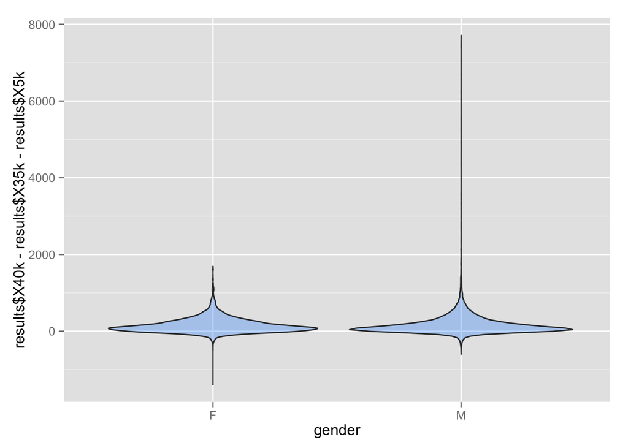

```r
#TODO: compute times over intervals similar to...
results$final_5k = results$X40k - results$X35k

#plot difference between first 5k and last 5k
ggplot(results, aes(x=gender, y=results$X40k - results$X35k-results$X5k)) + geom_violin(fill = "dodgerblue", alpha = 0.3)
```

# Appendix: Extra Plots and Exploratory Analysis

#### How is pace related to age group?

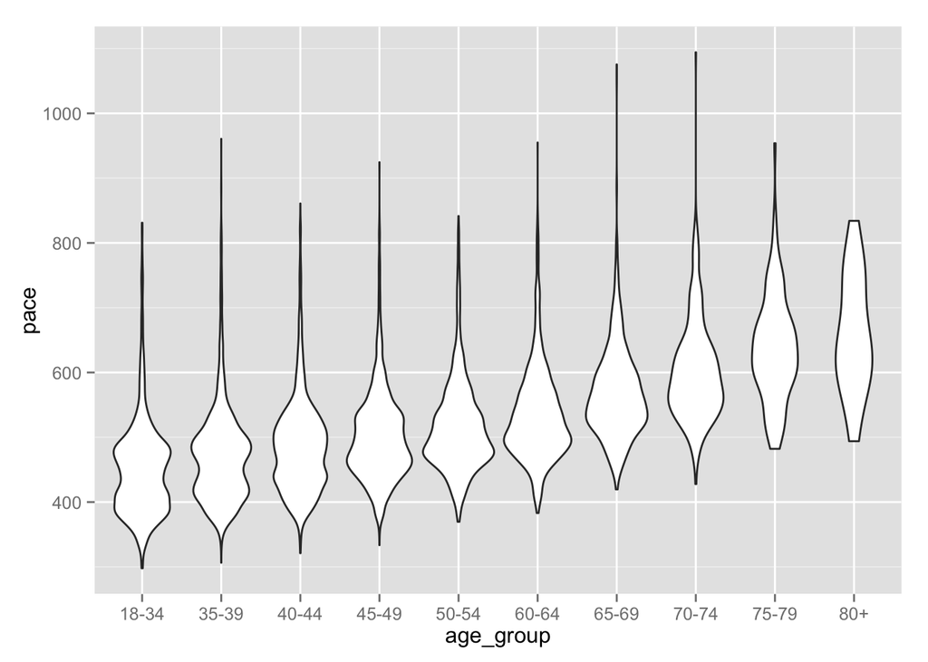

```r
ggplot(results[results$age_group!="NA",], aes(x=age_group, y=pace)) + geom_violin()
```

```r
#note: these are interesting graphs but need a little more wrangling to come out right!

#ggplot(results, aes(x = bib_number, y = overall_place)) + geom_point()
#ggplot(results, aes(x = bib_number, y = overall_place)) + stat_binhex()
```